# Emotional Granularity IRR

Author

Hoemann, Simmons, & Girard

Published

May 29, 2026

# Setup

```r
library(tidyverse)
library(simhelpers)
library(gt)
library(paletteer)
library(ggpubr)
library(gtExtras)
library(vardel)
library(purrr)
```

# Load data

```r
dat <- read_csv("~/Documents/Github/MastersThesis/iccs/data/fullsets/IRR_Emotional_Granularity.csv")
```

# Data Wrangling

```r
dat2 <- dat |>
  select(-1) |> # Drop the first column
  mutate(PPID= 1:n()) |> # Change PPID to numbers
  rename(RaterID = PPID) |> #rename
  pivot_longer(
    cols = 2:273,  #everything except the first column
    names_to = "ObjectID",
    values_to = "Score"
    ) |>
    separate_wider_delim(
        cols = "ObjectID",
        delim = "_",
        names = c("EmotionID", "ImageID")
    )

dat2
```

```
# A tibble: 27,472 × 4
   RaterID EmotionID   ImageID Score
     <int> <chr>       <chr>   <dbl>
 1       1 ANGSTIG     P           0
 2       1 BEDROEFD    P           0
 3       1 BOOS        P           0
 4       1 DEPRESSIEF  P           0
 5       1 EENZAAM     P           0
 6       1 GEGENEERD   P           0
 7       1 GEÏRRITEERD P           0
 8       1 ONGELUKKIG  P           0
 9       1 ONGERUST    P           1
10       1 RAZEND      P           0
# ℹ 27,462 more rows
```

# Analysis

Need to obtain ICC per rater, such that for each rater - ‘rater’ = emotion - ‘object’ = image id

## Using the AOV framework

```r
emotions_aov <- dat2 %>%
    filter(ImageID != "P") |> # don't use practice items |>
    rename(ObjectID = ImageID) %>% # rename to work with functions in {vardel}
    rename(Participants = RaterID) %>% # rename to work with functions in {vardel}
    rename(RaterID = EmotionID) %>% # rename to work with functions in {vardel}
    group_by(Participants) %>%
    group_modify(~ calc_aov_icc(.x))
emotions_aov
```

```
# A tibble: 404 × 12
# Groups:   Participants [101]
   Participants method  icc   estimate ci_lower ci_upper       vs      vr    vsr
          <int> <chr>   <chr>    <dbl>    <dbl>    <dbl>    <dbl>   <dbl>  <dbl>
 1            1 aov_icc ICC(…  0.0996    0.0294   0.262   8.60e-2 2.92e-2 0.748
 2            1 aov_icc ICC(…  0.639     0.327    0.850   8.60e-2 2.92e-2 0.748
 3            1 aov_icc ICC(…  0.103     0.0304   0.270   8.60e-2 2.92e-2 0.748
 4            1 aov_icc ICC(…  0.648     0.334    0.855   8.60e-2 2.92e-2 0.748
 5            2 aov_icc ICC(… -0.00201  -0.0311   0.0770 -6.94e-5 4.51e-4 0.0342
 6            2 aov_icc ICC(… -0.0331   -0.932    0.572  -6.94e-5 4.51e-4 0.0342
 7            2 aov_icc ICC(… -0.00204  -0.0315   0.0779 -6.94e-5 4.51e-4 0.0342
 8            2 aov_icc ICC(… -0.0336   -0.956    0.575  -6.94e-5 4.51e-4 0.0342
 9            3 aov_icc ICC(…  0.0994    0.0306   0.259   2.61e-1 2.05e-1 2.16
10            3 aov_icc ICC(…  0.638     0.335    0.848   2.61e-1 2.05e-1 2.16
# ℹ 394 more rows
# ℹ 3 more variables: message <chr>, warning <chr>, error <chr>
```

## Using the g_ICC framework

```r
emotions_gicc <- dat2 %>%
    filter(ImageID != "P") |> # don't use practice items |>
    rename(ObjectID = ImageID) %>% # rename to work with functions in {vardel}
    rename(Participants = RaterID) %>% # rename to work with functions in {vardel}
    rename(RaterID = EmotionID) %>% # rename to work with functions in {vardel}
    group_by(Participants) %>%
    group_modify(~ calc_g_ordinal_icc(.x))

emotions_gicc
```

```
# A tibble: 404 × 13
# Groups:   Participants [101]
   Participants method icc      estimate ci_lower ci_upper sigma_vsr     vs
          <int> <chr>  <chr>       <dbl>    <dbl>    <dbl>     <dbl>  <dbl>
 1            1 g_icc  ICC(A,1)   0.0759  0.00692    0.492         1 0.120
 2            1 g_icc  ICC(A,k)   0.568   0.100      0.939         1 0.120
 3            1 g_icc  ICC(C,1)   0.107   0.00972    0.595         1 0.120
 4            1 g_icc  ICC(C,k)   0.658   0.136      0.959         1 0.120
 5            2 g_icc  ICC(A,1)   0.0321 NA         NA             1 0.0331
 6            2 g_icc  ICC(A,k)   0.346  NA         NA             1 0.0331
 7            2 g_icc  ICC(C,1)   0.0321 NA         NA             1 0.0331
 8            2 g_icc  ICC(C,k)   0.346  NA         NA             1 0.0331
 9            3 g_icc  ICC(A,1)   0.164   0.0546     0.401         1 0.246
10            3 g_icc  ICC(A,k)   0.759   0.480      0.915         1 0.246
# ℹ 394 more rows
# ℹ 5 more variables: vr <dbl>, vsr <dbl>, message <chr>, warning <chr>,
#   error <chr>
```

# Comparing Frameworks

First combine all the results

```r
emotions_full <- bind_rows(emotions_aov, emotions_gicc)
emotions_full$method <- as.factor(emotions_full$method)
```

Compare via boxplots

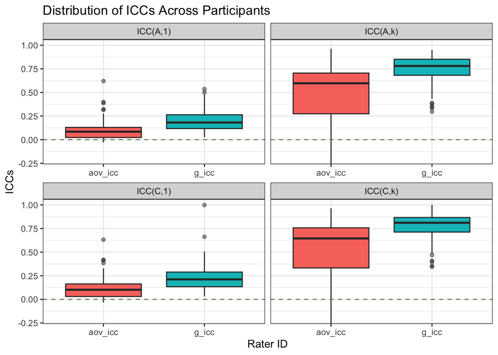

```r
ggplot(emotions_full, aes(x = method, y = estimate, fill = method)) +
  geom_boxplot(outlier.alpha = 0.5) +
  theme_bw() +
  facet_wrap(~ icc, scales = "free_x") +
  coord_cartesian(ylim = c(-.20, 1)) +
  geom_hline(yintercept = 0, color = "lemonchiffon4", linetype = "dashed", linewidth = 0.5) +
  labs(
    title = "Distribution of ICCs Across Participants",
    x = "Rater ID",
    y = "ICCs"
  ) +
  theme(
   # axis.text.x = element_text(angle = 45, hjust = 1, size = 8),
    legend.position = "none"
  )
```

# Negative ICCs

We see negative ICCs in ANOVA framework

```r
negative_iccs <- emotions_full |>
    filter(estimate< 0)
filt_participants <- unique(negative_iccs$Participants)
```

These same participants do not have negative ICCs in the g-ICC framework

```r
emotions_full |>
    filter(Participants %in% filt_participants) |>
    select(Participants,method,icc,estimate) |>
    print(n=56)
```

```
# A tibble: 56 × 4
# Groups:   Participants [7]
   Participants method  icc      estimate
          <int> <fct>   <chr>       <dbl>
 1            2 aov_icc ICC(A,1) -0.00201
 2            2 aov_icc ICC(A,k) -0.0331
 3            2 aov_icc ICC(C,1) -0.00204
 4            2 aov_icc ICC(C,k) -0.0336
 5           20 aov_icc ICC(A,1) -0.0123
 6           20 aov_icc ICC(A,k) -0.241
 7           20 aov_icc ICC(C,1) -0.0132
 8           20 aov_icc ICC(C,k) -0.263
 9           21 aov_icc ICC(A,1) -0.0233
10           21 aov_icc ICC(A,k) -0.573
11           21 aov_icc ICC(C,1) -0.0273
```

[output cut: 45 more lines]

## Rank Comparisons

### Rank-Rank Scatter plot

- Shows us where each participant is ranked by one method to the other method.
- The 45 degree line is one-to-one mapping between methods

```r
wide_emotions_full <- emotions_full |>
    group_by(method, icc) |>
    mutate(Rank = rank(estimate)) |>
    ungroup() |>
    select(Participants, method, icc, Rank) |>
    pivot_wider(
        names_from = method,
        values_from = Rank,
        names_prefix = "Rank_"
    )
wide_emotions_full
```

```
# A tibble: 404 × 4
   Participants icc      Rank_aov_icc Rank_g_icc
          <int> <chr>           <dbl>      <dbl>
 1            1 ICC(A,1)           59         13
 2            1 ICC(A,k)           59         13
 3            1 ICC(C,1)           52         18
 4            1 ICC(C,k)           52         18
 5            2 ICC(A,1)            7          3
 6            2 ICC(A,k)            7          3
 7            2 ICC(C,1)            7          1
 8            2 ICC(C,k)            7          1
 9            3 ICC(A,1)           58         45
10            3 ICC(A,k)           58         45
# ℹ 394 more rows
```

**Note that the larger ranks have the highest ICC value within method and icc type**

Plotting

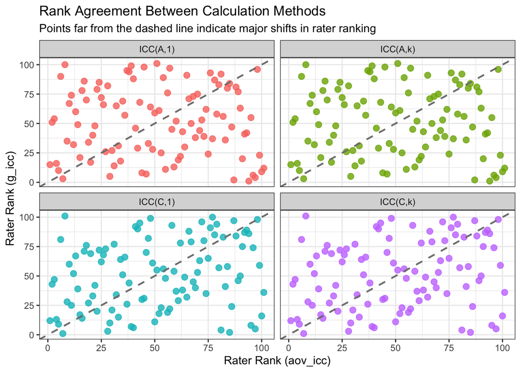

```r
method_names <- colnames(wide_emotions_full)[3:4]

ggplot(wide_emotions_full,
aes(
    x = .data[[method_names[1]]],
    y = .data[[method_names[2]]],
    color = icc)) +
  geom_point(size = 2.5, alpha = 0.8) +
  # The 45-degree reference line: perfect rank agreement sits exactly on this line
  geom_abline(intercept = 0, slope = 1, linetype = "dashed", color = "grey50", size = 0.8) +
  facet_wrap(~ icc) +
  #scale_x_reverse() + # Optional: Puts Rank 1 at the top/left instead of the bottom
  #scale_y_reverse() +
  theme_bw() +
  labs(
    title = "Rank Agreement Between Calculation Methods",
    subtitle = "Points far from the dashed line indicate major shifts in rater ranking",
    x = paste("Rater Rank (", gsub("Rank_", "", method_names[1]), ")", sep=""),
    y = paste("Rater Rank (", gsub("Rank_", "", method_names[2]), ")", sep=""),
    color = "ICC Level"
  ) +
    theme(
        legend.position = "none"
    )
```

**We can conclude that the two methods greatly changed participant ranks** I think this is to be expected, given that the g_icc is less biased. For example, some participants obtained negative ICC values in the ANOVA framework, whereas the no participant obtained a negative ICC value in the g_icc framework.

### Bland-Altman Plot (Tukey mean-difference plot)

This shows us the differences in rank for each participant

```r
rank_cols <- colnames(wide_emotions_full)[3:4]
ba_data <- wide_emotions_full %>%
  mutate(
    Rank_Mean = (.data[[rank_cols[1]]] + .data[[rank_cols[2]]]) / 2,
    Rank_Diff = .data[[rank_cols[1]]] - .data[[rank_cols[2]]]
  )
ba_data
```

```
# A tibble: 404 × 6
   Participants icc      Rank_aov_icc Rank_g_icc Rank_Mean Rank_Diff
          <int> <chr>           <dbl>      <dbl>     <dbl>     <dbl>
 1            1 ICC(A,1)           59         13      36          46
 2            1 ICC(A,k)           59         13      36          46
 3            1 ICC(C,1)           52         18      35          34
 4            1 ICC(C,k)           52         18      35          34
 5            2 ICC(A,1)            7          3       5           4
 6            2 ICC(A,k)            7          3       5           4
 7            2 ICC(C,1)            7          1       4           6
 8            2 ICC(C,k)            7          1       4           6
 9            3 ICC(A,1)           58         45      51.5        13
10            3 ICC(A,k)           58         45      51.5        13
# ℹ 394 more rows
```

Plotting

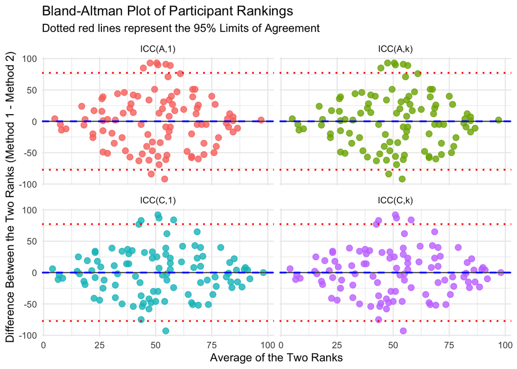

```r
# Calculate overall bias and Limits of Agreement (LoA)
bias <- mean(ba_data$Rank_Diff, na.rm = TRUE)
sd_diff <- sd(ba_data$Rank_Diff, na.rm = TRUE)
upper_loa <- bias + (1.96 * sd_diff)
lower_loa <- bias - (1.96 * sd_diff)

# Create the Bland-Altman Plot faceted by ICC
ggplot(ba_data, aes(x = Rank_Mean, y = Rank_Diff, color = icc)) +
  geom_point(size = 2.5, alpha = 0.8) +
  facet_wrap(~ icc) +

  # Horizontal line at 0 (Perfect Agreement)
  geom_hline(yintercept = 0, linetype = "solid", color = "grey30") +

  # Mean Bias Line
  geom_hline(yintercept = bias, linetype = "dashed", color = "blue", size = 0.8) +

  # Upper and Lower Limits of Agreement
  geom_hline(yintercept = upper_loa, linetype = "dotted", color = "red", size = 0.8) +
  geom_hline(yintercept = lower_loa, linetype = "dotted", color = "red", size = 0.8) +

  facet_wrap(~ icc) +
  theme_minimal() +
  labs(
    title = "Bland-Altman Plot of Participant Rankings",
    subtitle = "Dotted red lines represent the 95% Limits of Agreement",
    x = "Average of the Two Ranks",
    y = "Difference Between the Two Ranks (Method 1 - Method 2)",
    color = "ICC Level"
  ) +
    theme(
        legend.position = "none"
    )
```

[output not shown]

We can pin-point which participants had the largest rank-differnces relative to their rank-mean across methods

```r
ba_data |>
    filter(Rank_Diff > upper_loa | Rank_Diff < lower_loa)
```

```
# A tibble: 26 × 6
   Participants icc      Rank_aov_icc Rank_g_icc Rank_Mean Rank_Diff
          <int> <chr>           <dbl>      <dbl>     <dbl>     <dbl>
 1           19 ICC(A,1)          100          9      54.5        91
 2           19 ICC(A,k)          100          9      54.5        91
 3           19 ICC(C,1)          100         16      58          84
 4           19 ICC(C,k)          100         16      58          84
 5           27 ICC(A,1)          101         12      56.5        89
 6           27 ICC(A,k)          101         12      56.5        89
 7           33 ICC(A,1)            6         90      48         -84
 8           33 ICC(A,k)            6         90      48         -84
 9           92 ICC(A,1)            8        100      54         -92
10           92 ICC(A,k)            8        100      54         -92
# ℹ 16 more rows
```

### Counter-factual Bland-Altman plot

To confirm, let’s consider a counter-factual Bland-Altman plot if both `aov_icc` and `g_icc` had the same rankings (using the same plot code).

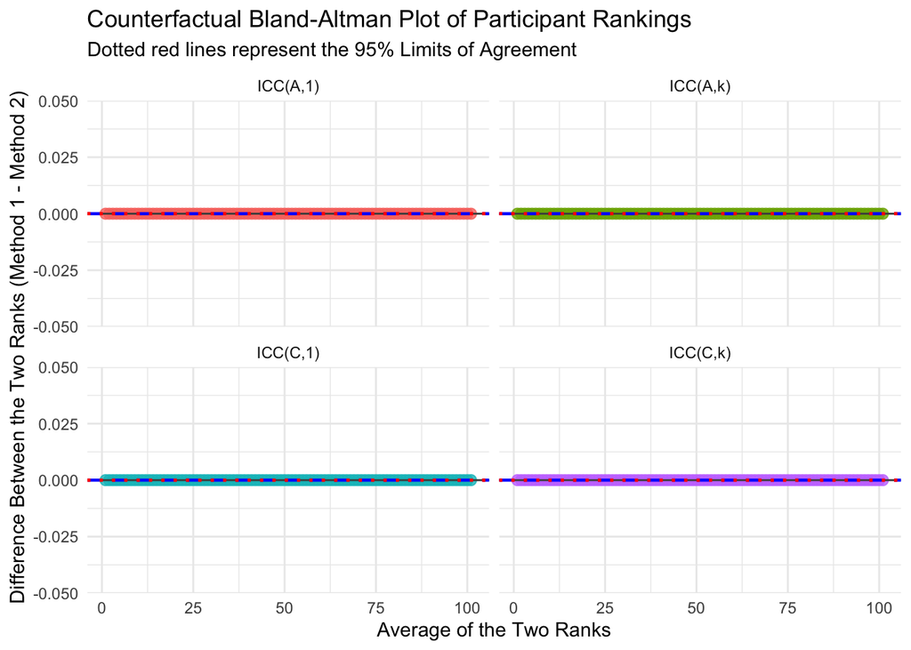

```r
ba_data_counterfactual <- ba_data |>
    group_by(icc) |>
    mutate(Rank_aov_icc = 1:n(),
    Rank_g_icc = 1:n()) |>
  mutate(
    Rank_Mean = (.data[[rank_cols[1]]] + .data[[rank_cols[2]]]) / 2,
    Rank_Diff = .data[[rank_cols[1]]] - .data[[rank_cols[2]]]
  )

  # Calculate overall bias and Limits of Agreement (LoA)
bias <- mean(ba_data_counterfactual$Rank_Diff, na.rm = TRUE)
sd_diff <- sd(ba_data_counterfactual$Rank_Diff, na.rm = TRUE)
upper_loa <- bias + (1.96 * sd_diff)
lower_loa <- bias - (1.96 * sd_diff)

# Create the Bland-Altman Plot faceted by ICC
ggplot(ba_data_counterfactual, aes(x = Rank_Mean, y = Rank_Diff, color = icc)) +
  geom_point(size = 2.5, alpha = 0.8) +
  facet_wrap(~ icc) +

  # Horizontal line at 0 (Perfect Agreement)
  geom_hline(yintercept = 0, linetype = "solid", color = "grey30") +

  # Mean Bias Line
  geom_hline(yintercept = bias, linetype = "dashed", color = "blue", size = 0.8) +

  # Upper and Lower Limits of Agreement
  geom_hline(yintercept = upper_loa, linetype = "dotted", color = "red", size = 0.8) +
  geom_hline(yintercept = lower_loa, linetype = "dotted", color = "red", size = 0.8) +

  facet_wrap(~ icc) +
  theme_minimal() +
  labs(
    title = "Counterfactual Bland-Altman Plot of Participant Rankings",
    subtitle = "Dotted red lines represent the 95% Limits of Agreement",
    x = "Average of the Two Ranks",
    y = "Difference Between the Two Ranks (Method 1 - Method 2)",
    color = "ICC Level"
  ) +
    theme(
        legend.position = "none"
    )
```